# Finel lab

ID : 206197378

8 8 2019

```r
set.seed(101)
library(readr)
library(rpart)
library(rpart.plot)
library(ggplot2)
library(dplyr)
library(caret)
```

**load data**

```r
News <- read_csv("C:/Users/Admin/Desktop/finel lab/News.csv")
news_to_work <- News[,-c(1,2,3)]
validation_X <- read_csv("validation_X.csv")
```

# Question 1

## Exploratory Data Analysis

### First predictor

We want to check the relationship between the channel where the article was published and the amount of sharing. It seems reasonable to think that on social media we will have the most shares, because this is actually the channel where the most accessible and easy to share.

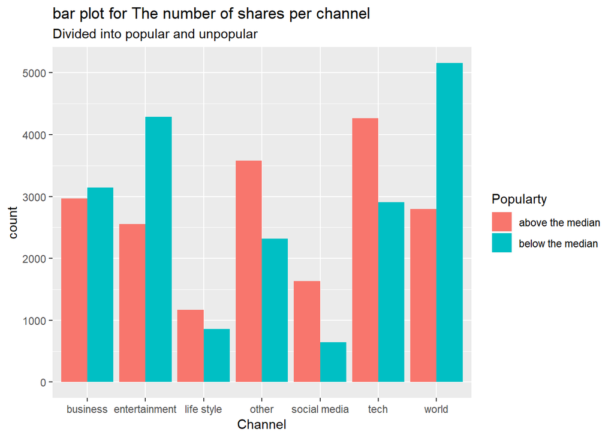

```r
c <- vector(length = nrow(news_to_work))
c[which(news_to_work$data_channel_is_lifestyle == 1)] <- "life style"
c[which(news_to_work$data_channel_is_entertainment == 1)] <- "entertainment"
c[which(news_to_work$data_channel_is_bus == 1)] <- "business"
c[which(news_to_work$data_channel_is_socmed == 1)] <- "social media"
c[which(news_to_work$data_channel_is_tech == 1)] <- "tech"
c[which(news_to_work$data_channel_is_world == 1)] <- "world"
c[which(c == FALSE)] <- "other"

Popularty <- vector(length = nrow(news_to_work) )
Popularty[which(sqrt(news_to_work$shares) > median(sqrt(news_to_work$shares)))] <- "above the median"
Popularty[which(sqrt(news_to_work$shares) <= median(sqrt(news_to_work$shares)))] <- "below the median"

ggplot(cbind.data.frame(c,news_to_work),aes( c,fill = Popularty))+geom_bar(position =   "dodge")+ xlab("Channel")+ggtitle("bar plot for The number of shares per channel", subtitle = "Divided into popular and unpopular")
```

```r
freq_table <- rbind.data.frame(table(Popularty,c)[1,]/table(c),table(Popularty,c)[2,]/table(c))
names(freq_table) <- names(table(c))
row.names(freq_table) <- c("above the median","below the median")
round(freq_table,3)*100
```

```
##                  business entertainment life style other social media tech
## above the median     48.6          37.3       57.6  60.7         71.7 59.4
## below the median     51.4          62.7       42.4  39.3         28.3 40.6
##                  world
## above the median  35.2
## below the median  64.8
```

Indeed, you can see that social media is actually far more in common than any other channel with almost 72%

### Second predictor

Now let’s look at whether articles published at the weekend share more than during the week. We might think so because people have more time to read articles and the more articles they read, the more articles they may share.

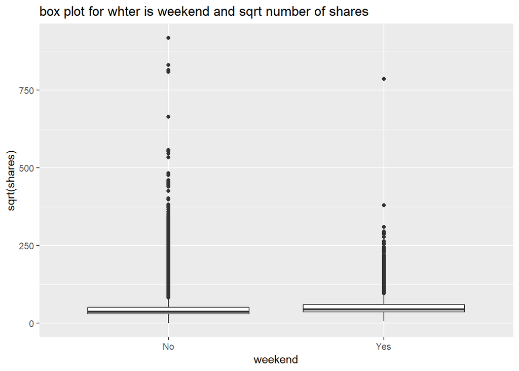

```r
weekend <- vector(length = nrow(news_to_work))
weekend[which(news_to_work$is_weekend == 1)] <- "Yes"
weekend[which(news_to_work$is_weekend == 0)] <- "No"

ggplot(as.data.frame(news_to_work),aes(x = weekend, y = sqrt(shares))) + geom_boxplot() + ggtitle("box plot for whter is weekend and sqrt number of shares")
```

You can see that the median of a weekend is just over the median of course of the week, But not as much as we would expect. far more extreme values during the week than at the weekend.

# Question 2

## Q2.a Split the data

Arrange the News data to test data and training data, useing timedelta column which shows the time since it was published until the time it entered the study data

```r
que <- quantile(News$timedelta, 0.7)
que <- c(que,Inf)
train_ind <- c()
tast_ind <- c()



train_data <- news_to_work[which(News$timedelta <= que),]
test_data <- news_to_work[-which(News$timedelta <= que),]


y_train <- sqrt(train_data$shares)
x_train <- train_data[,-59]


y_test <- sqrt(test_data$shares)
x_test <- test_data[,-59]
```

## Q2.b Implemention Random Forest

The function takes as input an x matrix of explanatory variables of $n*p$ size, vector y of the variable explained size $n*1$ and number of trees. The function builds as many trees as it has received and puts them into a list. It then inserts the predicted values into a matrix so that each column is an expected value vector and then it averages over each row. The function returns as a list output that contains the average predicted values of all trees and a list of all trees.

```r
my_rf <- function(x,y,num_tree,my_cp,maxd,mins){
  lst <- list()
  p_vec <- list()
  for (i in 1:num_tree){
    p <- sample(c(1:ncol(x)),size = sqrt(ncol(x)))
    p_vec[[i]] <- p
    sam <- sample(c(1:nrow(x)),nrow(x),replace = T)
    tre <- rpart(formula = y ~.,data = x[sam,p] , method  = "anova" , control = list(cp =  my_cp ,minsplit = mins, maxdepth = maxd))
    lst[[i]] <- tre
  }
  mat_tree <- matrix(nrow = nrow(x), ncol = num_tree)

  for (j in 1:length(lst)){
    mat_tree[,j] <- predict(lst[[j]],newdata = x)
  }
  y_hat1 <- apply(mat_tree, 1, mean)
  return(list(y_hat = y_hat1,model = lst,mat_tree,p = p_vec))
}
```

```r
predict_my_rf <- function(rfmodel,x,p){
  mat_pre <- matrix( nrow = nrow(x), ncol = length(rfmodel))
  for (i in 1:length(rfmodel)) {
    mat_pre[,i] <- predict(rfmodel[[i]], newdata = x[,p[[i]]])
  }
  y_pre <- apply(mat_pre,1,mean)
  return(y_pre)
}
```

## Q2.c.1 optimize the parameters

```r
hyper_grid = expand.grid(
  minsplit=seq(5, 20, 1),
  maxdepth=seq(8, 15, 1)
)


models = list()
for (i in 1:nrow(hyper_grid)){
  minsplit = hyper_grid$minsplit[i]
  maxdepth = hyper_grid$maxdepth[i]

  models[[i]] = rpart(
    formula = y_train ~ .,
    data = x_train,
    method = 'anova',
    control = list(minsplit=minsplit, maxdepth=maxdepth)
  )
}


get_cp = function(x){
  min = which.min(x$cptable[, 'xerror'])
  cp = x$cptable[min, 'CP']
}

get_min_error = function(x){
  min = which.min(x$cptable[, 'xerror'])
  xerror = x$cptable[min, 'xerror']
}

premtar <- hyper_grid %>%
  mutate(
    cp = purrr::map_dbl(models, get_cp),
    error = purrr::map_dbl(models, get_min_error)
  ) %>%
  arrange(error) %>%
  top_n(-5, wt=error)

mins <- premtar$minsplit[1]
maxd <- premtar$maxdepth[1]

premtar
```

```
##   minsplit maxdepth   cp     error
## 1        9       10 0.01 0.9585589
## 2       13        8 0.01 0.9585797
## 3        7       14 0.01 0.9586014
## 4       10        9 0.01 0.9586140
## 5       15       13 0.01 0.9586164
```

## Q2.c.2 prediction accuracy (rmse) as a function of the number of trees

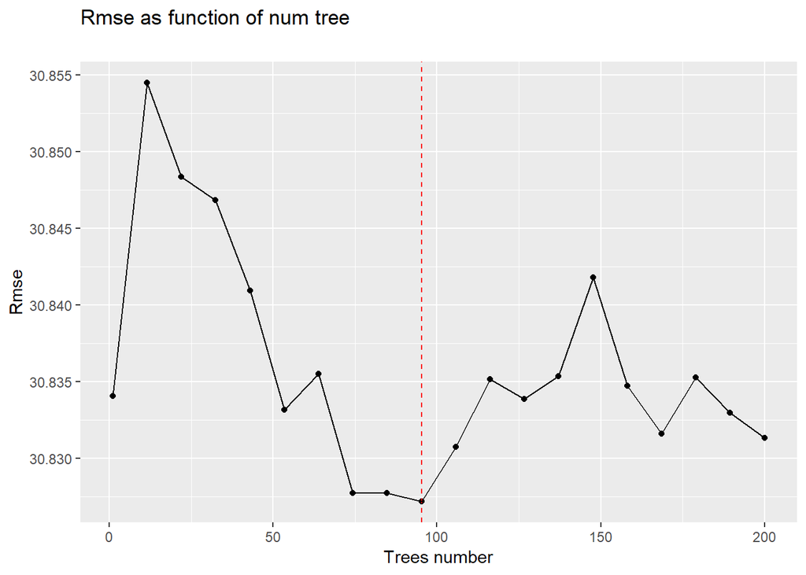

```r
upto <- seq(from = 1,to = 200 ,length.out = 20)
vec_of_rmse <- c()
for (i in upto){
  forst <- my_rf(x = x_train,y = y_train,num_tree = i,my_cp = 0.0006,maxd = maxd,mins = mins)
  pre <- predict_my_rf(rfmodel = forst[[2]],x_test,p =forst[[4]] )
  vec_of_rmse <- c(vec_of_rmse,sqrt(sum((y_test-pre)^2)/length(pre)))
}


g <- ggplot(data = cbind.data.frame(upto,vec_of_rmse),aes(x = upto,y=vec_of_rmse))+geom_point()+geom_vline(aes(xintercept = upto[which.min(vec_of_rmse)]),col = "red",lty = "dashed")+geom_line()+xlab("Trees number") + ylab("Rmse") + ggtitle("Rmse as function of num tree",subtitle = "")

g
```

## Q2.d Residual

### Q2.d Residual vector characterize

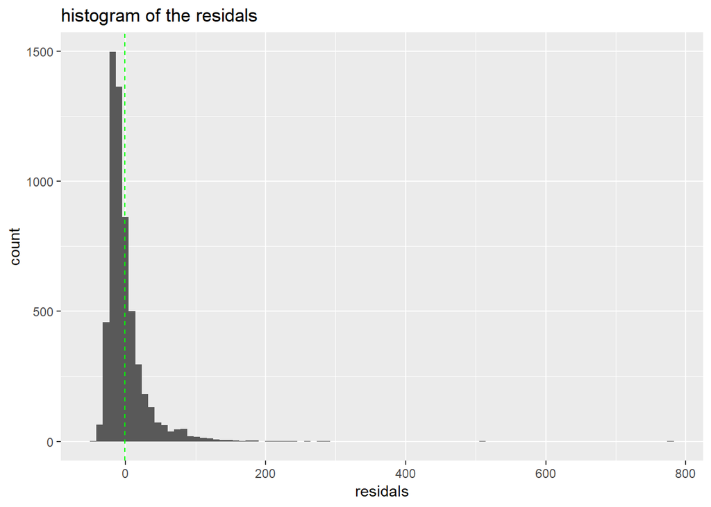

```r
modelrf <- my_rf(x = x_train,y= y_train,num_tree = round(upto[which.min(vec_of_rmse)],0),my_cp = 0.0006,maxd = maxd,mins = mins)
pre <- predict_my_rf(modelrf[[2]],x = x_test,p = modelrf[[4]])
residualsrf <- unlist(y_test) - pre

ggplot(data = as.data.frame(residualsrf),aes(x = residualsrf))+geom_histogram(bins = 90)+geom_vline(xintercept = mean(residualsrf),col = "green",lty = "dashed") + ggtitle("histogram of the residals") + xlab("residals")
```

```r
pre_extrim_val <- round(sum(residualsrf> 200)/length(residualsrf)*100,2)
```

Looks like we have a relatively nice distribution around the 0. Although there are really extreme values on the right of the distribution, they are negligible (equal to 0.19% larger than 200)

Now let’s look at how the residual vector behaves versus the prediction vector. Maybe we can learn from there about homogeneity of the variance.

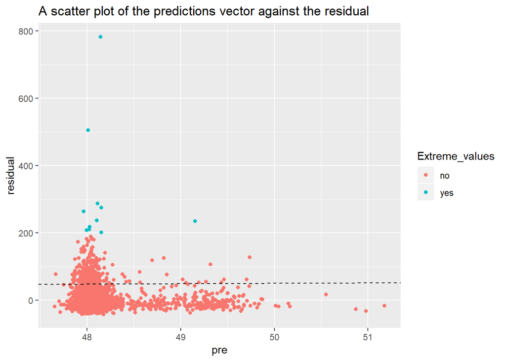

```r
Extreme_values <- residualsrf> 200
Extreme_values[Extreme_values] <- "yes"
Extreme_values[which(Extreme_values == FALSE)] <- "no"
Extreme_values <- factor(Extreme_values)

ggplot(as.data.frame(x_test),aes(y = residualsrf, x = pre)) + geom_point(aes(colour = Extreme_values)) + ggtitle("A scatter plot of the predictions vector against the residual") + geom_abline(intercept = 0 , slope = 1, lty = "dashed") + xlab("pre")+ylab("residual")
```

You can see that almost all the values above the identity equation have a certain pattern that goes up, and the values below have no such pattern. We will try to examine those above the line to those below. We will divide them by those over 50 will be those above

### Q2.d.2 the kind of articles

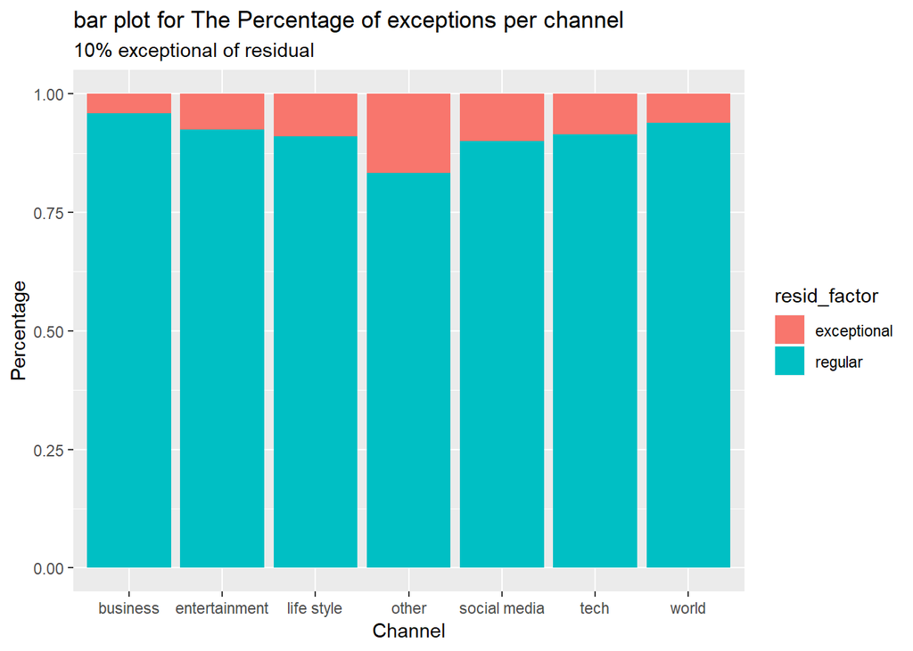

```r
resi_que <- quantile(abs(residualsrf),0.9)
resid_factor <- ifelse(residualsrf <= resi_que,"regular","exceptional")

ggplot(cbind.data.frame(resid_factor,x_test),aes( c[-which(News$timedelta <= que)],fill = resid_factor))+geom_bar(position =   "fill")+ xlab("Channel")+ggtitle("bar plot for The Percentage of exceptions per channel", subtitle = "10% exceptional of residual")+ylab("Percentage")
```

You can see that according to the graph we saw in question 1(As stated we examined the relationship between the various channels and the amount of sharing) here also the channel “Other” has the most unusual points left behind after “Social Media”, “Lifestyle”, “Technology” and “Entertainment” which is a relative exception to the results in Question 1

Here you can see the percentages of each channel:

```r
tt <- round((table(c[-which(News$timedelta <= que)],resid_factor)[,1]/table(c))*100,2)
tt
```

```
## c
##      business entertainment    life style         other  social media
##          0.65          1.01          1.82          2.71          1.97
##          tech         world
##          1.51          0.57
```

# Question 3

In this question I will use the model $Gradient Boosting$ to predict the root of the number of article shares

```r
my_prediction_model <- function(valid_x ,x_traini,y_traini,x_testi,y_testi){
  xgb_trcontrol = trainControl(
    method = "cv",
    number = 5,
    allowParallel = TRUE,
    verboseIter = FALSE,
    returnData = FALSE
  )

  xgbGrid <- expand.grid(nrounds = c(100,200),
                         max_depth = c(10, 15, 20, 25),
                         colsample_bytree = seq(0.5, 0.9, length.out = 5),
                         eta = 0.1,
                         gamma=0,
                         min_child_weight = 1,
                         subsample = 1
                        )

  xgb_model = train(
    x_traini, y_traini,
    trControl = xgb_trcontrol,
    tuneGrid = xgbGrid,
    method = "xgbTree"
  )

  pred = predict(xgb_model, x_testi)
  Rmse = sqrt((sum(y_testi - pred)^2)/length(y_testi))
  sst = sum((y_testi - mean(y_testi))^2)
  sse = sum((y_testi - pred)^2)
  acc = sse/sst
  std_mod = acc*(1-acc)
  my_id = 302900683
  prd_valid <- predict(xgb_model, validation_X[,-c(1,2,3)])
  lst_model <- list("my_id" = my_id,"predicted_accuracy" = Rmse,"estimated_stderr" = std_mod,"prediction" = prd_valid)
  save(lst_model,file = "model.RData")
  return(lst_model)
}
my_ans <-my_prediction_model(valid_x = validation_X,x_traini = x_train,y_traini = y_train,x_testi = x_test,y_testi = y_test)
```